# 2º Experimento utilizando Regressão logística e features de contratos associados a obras

Para este experimento foi feito um cruzamento dos dados de obras presente no Banco de Obras (TCE) com a base de dados do SAGRES. O objetivo é utilizar os dados de contratos relacionados a obras para o treinamento de um modelo de previsão do status do contrato.

# Modelo Regressão Logística usando dados de Obras e features do SAGRES (experimento 1)

A primeira fase deste experimento considera todos os dados de contratos associados a Obras entre os anos de 2011 e 2016. A origem destes anos é obtida nas informações de contrato presentes na base do SAGRES. Um conjunto de features foram geradas considerando informações sobre o contrato mas também informações sobre a empresa até o dia da assinatura do contrato. As features utilizadas são:

- Valor do contrato. Presente nas informações (tabela) de contratos do SAGRES
- Tipo da licitação que gerou o contrato
- Número de Municípios que a empresa forneceu (tem empenho associado). Uma feature para cada ano entre 2011 e 2016 e uma feature para média.
- Número de Unidades Gestoras que a empresa forneceu (tem empenho associado). Uma feature para cada ano entre 2011 e 2016 e uma feature para média.
- Total ganho pela empresa (considerando estornos de pagamentos). Uma feature para cada ano entre 2011 e 2016 e uma feature para média.
- Montante do valor das licitações que a empresa venceu. Uma feature para cada ano entre 2011 e 2016 e uma feature para média.
- Número de licitações que a empresa participou (lançou pelo menos uma proposta). Uma feature para cada ano entre 2011 e 2016 e uma feature para média.
- Número de licitações que a empresa venceu (está associada a pelo menos um empenho que está ligado a uma licitação). Uma feature para cada ano entre 2011 e 2016 e uma feature para média.
- Percentual de vitória da empresa (número de licitações vencidas / número de licitações que participou). Uma feature para cada ano entre 2011 e 2016 e uma feature para média.
- Número de propostas que a empresa fez em licitações. Uma feature para cada ano entre 2011 e 2016 e uma feature para média.
- Número de contratos anteriores ao contrato de interesse (observação) que teve seu status considerado Finalizado Judicialmente ou Administrativamente (leva em consideração o status da obra).
- Número de contratos anteriores ao contrato de interesse (observação) que teve seu status considerado Abandonado (leva em consideração o status da obra).
- Razão entre o valor do contrato e o valor recebido pela empresa.
- Número de contratos que a empresa está associada, considerando contratos anteriores ao contrato de interesse. Uma feature para cada ano entre 2011 e 2016 e uma feature para média.

Os dados foram divididos em dois subconjuntos: treino (80%) e teste (20%). Existem features que possuem valor NA para algumas observações. Para esta primeira etapa estas observações serão removidas.

Os valores absolutos e relativos das classes de contrato dentro do conjunto de dados estão apresentado a seguir

| Classe | Número de observações |
| --- | --- |
| 0 | 106 |
| 1 | 118 |

| Classe | Porcentagem |
| --- | --- |
| 0 | 0.473214285714286 |
| 1 | 0.526785714285714 |

O modelo foi treinado utilizando apenas os dados de treino, aplicando o método glm e usando cross-validation.

A avaliação do modelo é feita utilizando os dados de teste, que correspondem a 20% dos dados originais e não foram utilizados durante o treinamento do modelo.

As métricas utilizadas são F1 e AUC (área sob a curva), apresentadas, respectivamente, a seguir

```
## [1] 0.6341463
```

```
## Area under the curve: 0.6636
```

A matriz de confusão e outras métricas é a seguinte

```
## Confusion Matrix and Statistics
##
##           Reference
## Prediction  0  1
##          0 16 10
##          1  5 13
##
##                Accuracy : 0.6591
##                  95% CI : (0.5008, 0.7951)
##     No Information Rate : 0.5227
##     P-Value [Acc > NIR] : 0.04748
##
##                   Kappa : 0.3238
##  Mcnemar's Test P-Value : 0.30170
##
##             Sensitivity : 0.7619
##             Specificity : 0.5652
##          Pos Pred Value : 0.6154
##          Neg Pred Value : 0.7222
##              Prevalence : 0.4773
##          Detection Rate : 0.3636
##    Detection Prevalence : 0.5909
##       Balanced Accuracy : 0.6636
##
##        'Positive' Class : 0
##
```

#### Considerando todas as observações

Na etapa anterior foram removidas as observações que continham NA em alguma de suas colunas. Para esta etapa se alguma feature tiver seu valor NA, o mesmo irá ser substituído por 0. O objetivo é comparar a influência dessa decisão no modelo.

Os valores absolutos e relativos das classes de contrato dentro do conjunto de dados estão apresentado a seguir.

| Classe | Número de observações |
| --- | --- |
| 0 | 129 |
| 1 | 136 |

| Classe | Porcentagem |
| --- | --- |
| 0 | 0.486792452830189 |
| 1 | 0.513207547169811 |

As métricas utilizadas são F1 e AUC (área sob a curva), apresentadas, respectivamente, a seguir.

```
## [1] 0.6296296
```

```
## Area under the curve: 0.6148
```

A matriz de confusão e outras métricas é a seguinte

```
## Confusion Matrix and Statistics
##
##           Reference
## Prediction  0  1
##          0 15 10
##          1 10 17
##
##                Accuracy : 0.6154
##                  95% CI : (0.4702, 0.747)
##     No Information Rate : 0.5192
##     P-Value [Acc > NIR] : 0.1054
##
##                   Kappa : 0.2296
##  Mcnemar's Test P-Value : 1.0000
##
##             Sensitivity : 0.6000
##             Specificity : 0.6296
##          Pos Pred Value : 0.6000
##          Neg Pred Value : 0.6296
##              Prevalence : 0.4808
##          Detection Rate : 0.2885
##    Detection Prevalence : 0.4808
##       Balanced Accuracy : 0.6148
##
##        'Positive' Class : 0
##
```

### Avaliação

A avaliação dos modelos treinados com relação a F1 e AUC pode ser observada na tabela a seguir.

| modelo | f1 | auc |
| --- | --- | --- |
| Regressão Logística (Removendo NA) | 0.63415 | 0.66356 |
| Regressão Logística (NA por 0) | 0.62963 | 0.61481 |

### Considerando o intervalo 2014-2016

Esta seção objetiva treinar e avaliar um modelo de regressão logística usando como features o conjunto apresentado nas seções anteriores mas tendo como dados de treino e de teste apenas contratos entre os anos de 2014 e 2016. A razão para esta parte do experimento está no fato de que existem mais informações sobre o label/status do contrato nesse intervalo de tempo.

A visualização a seguir mostra como se distribuem as classes positivas dentro de cada conjunto de dados utilizado.

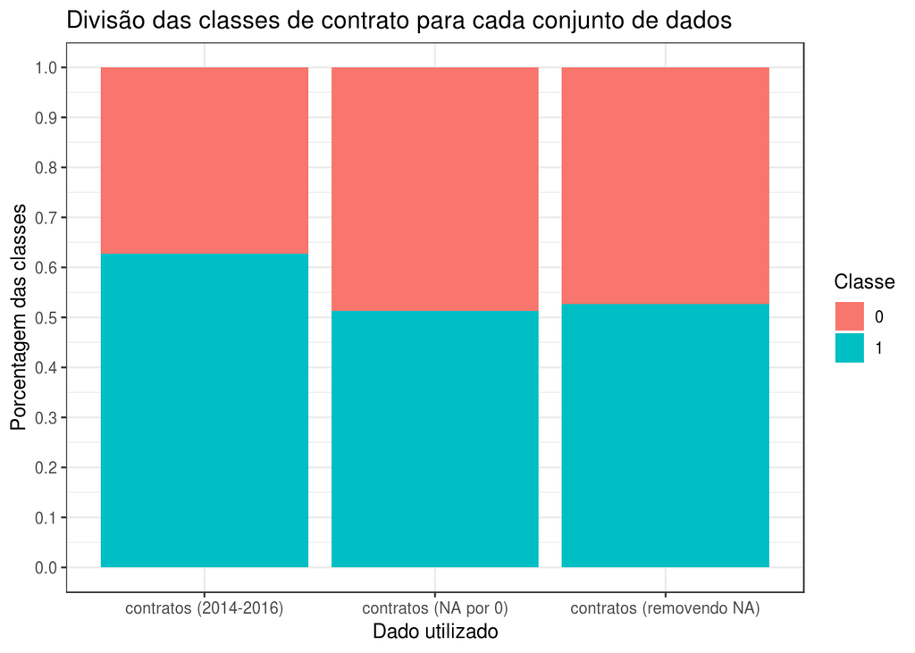

Como mostrado na visualização acima, o conjunto de dados considerando apenas os contratos entre 2014 e 2016 possui uma maior porcentagem de observações da classe positiva (contratos suspeitos) em comparação com a classe negativa.

#### Treinamento e avaliação do modelo

Os valores absolutos e relativos das classes de contrato dentro do conjunto de dados estão apresentado a seguir.

| Classe | Número de observações |
| --- | --- |
| 0 | 66 |
| 1 | 111 |

| Classe | Porcentagem |
| --- | --- |
| 0 | 0.372881355932203 |
| 1 | 0.627118644067797 |

As métricas utilizadas são F1 e AUC (área sob a curva), apresentadas, respectivamente, a seguir.

```
## [1] 0.8
```

```
## Area under the curve: 0.7168
```

A matriz de confusão e outras métricas é a seguinte

```
## Confusion Matrix and Statistics
##
##           Reference
## Prediction  0  1
##          0  8  4
##          1  5 18
##
##                Accuracy : 0.7429
##                  95% CI : (0.5674, 0.8751)
##     No Information Rate : 0.6286
##     P-Value [Acc > NIR] : 0.1086
##
##                   Kappa : 0.4405
##  Mcnemar's Test P-Value : 1.0000
##
##             Sensitivity : 0.6154
##             Specificity : 0.8182
##          Pos Pred Value : 0.6667
##          Neg Pred Value : 0.7826
##              Prevalence : 0.3714
##          Detection Rate : 0.2286
##    Detection Prevalence : 0.3429
##       Balanced Accuracy : 0.7168
##
##        'Positive' Class : 0
##
```

## Avaliação dos modelos

A avaliação considerando todos os modelos treinados até aqui está na tabela a seguir

Obs: o conjunto de teste para cada modelo é diferente.

| modelo | f1 | auc |
| --- | --- | --- |
| Regressão Logística (anos entre 2014 e 2016) | 0.8 | 0.71678 |
| Regressão Logística (Removendo NA) | 0.63415 | 0.66356 |
| Regressão Logística (NA por 0) | 0.62963 | 0.61481 |